# Analysis of live streaming of games on Twitch and Youtube by Lim Cheng Ian

### Q3. How has the proportion of gaming content changed for each site?

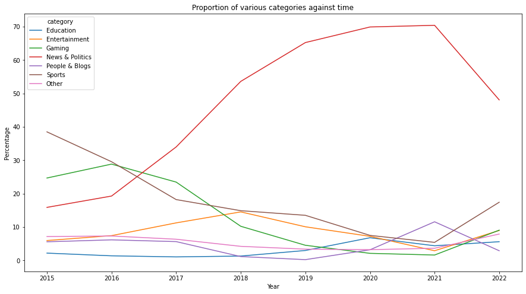

```python
area.plot(kind='line', figsize=(15,8))
plt.ylabel('Percentage')
plt.title('Proportion of various categories against time')
plt.show()
```

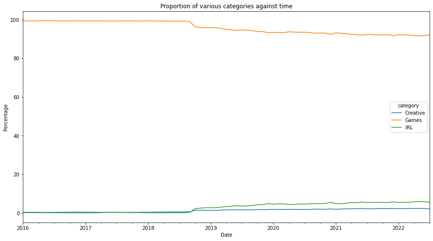

```python
twitch_area.plot(kind='line', figsize=(15,8))
plt.ylabel('Percentage')
plt.title('Proportion of various categories against time')
```

From this graph, we can see that the percentage of the total stream time that gaming has taken up has decreased since 2016, from close to 100% in 2016 to about 90% in July 2022. Conversely, the proportion of IRL streams and Creative streams have increased, from close to 0% for both in 2016 to around 7% for IRL and 3% for Creative. The proportion has remained more or less stable for the past 2 years.

In conclusion, Twitch remains a platform made for live streaming of games, still with a large percentage of streams being games. However, Youtube has always been a multipurpose platform with games not being its main focus, so the percentage is low. However, this percentage is on a decreasing trend for both of these platforms, although the effect is not very pronounced on Twitch.

### Q4. What are the top few games on each platform, and how has their stream time changed?

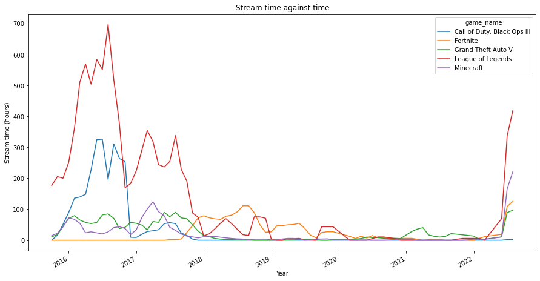

```python
q4ytmonthtime10.plot(kind='line', figsize=(15, 8))
plt.title('Stream time against time')
plt.xlabel('Year')
plt.ylabel('Stream time (hours)')
plt.show()
```

In this graph, we can see that up from 2016 to early 2022, the stream time for these games have generally decreased, with most of them getting a sudden spike in stream time in July 2022, except Call of Duty: Black Ops III. League of Legends is the most streamed game on Youtube, with the most streamed hours on Youtube in 2016 August, at 700 hours. Fortnite in particular, had a late burst in popularity in August 2017, but still died down by June 2020.

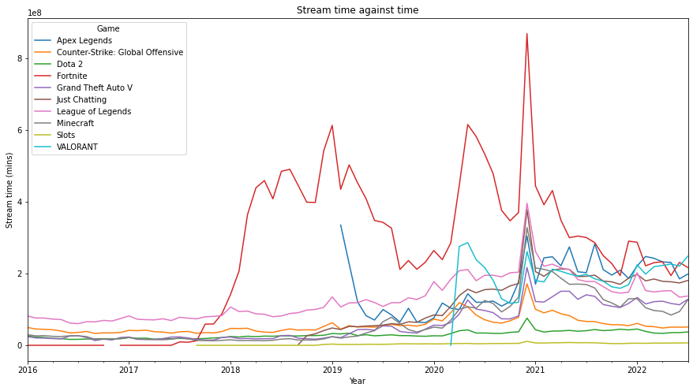

```python
q4tmonth10.plot(kind='line', figsize=(15,8))
plt.xlabel('Year')
plt.ylabel('Stream time (mins)')
plt.title('Stream time against time')
plt.show()
```

From this graph, we can see that Fortnite has the most amount of stream time and the highest streamed time per month in December 2020 at around 8.5e8 minutes of stream content. We can also see from this graph that there was a small increase in the stream time for most games in March-April 2020, showing how COVID-19 could have helped to boost Twitch and their stream time. There is also a sudden spike in December 2020, with the stream time increasing just for a month. In general, the stream time for these top games have increased slightly, but have stayed more or less constant in the past year.

In conclusion, the most streamed game on Youtube would be League of Legends, and Fortnite for Twitch. However, the stream time for games on Youtube is on a decreasing trend, with a sharp spike in July 2022, while it is on a slight increasing trend for Twitch with some stagnation in the past year.

### Q5. What is the relationship between the stream time and the number of followers gained for Twitch streamers?

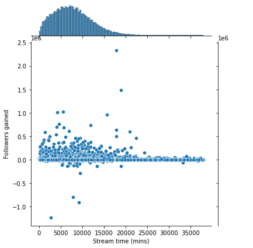

```python
sns.jointplot(x=q5twitch['Stream time (mins)'], y=q5twitch['Followers gained'], data=q5twitch)
```

```python
print('Equation of linear regression line:\ny=' + str(lm.intercept_.round(2)) + str(lm.coef_[0].round(4)) + 'x')
print(lm.score(X_train, y_train))
```

```
Equation of linear regression line:
y=6240.73-0.0529x
9.912513583021365e-05
```

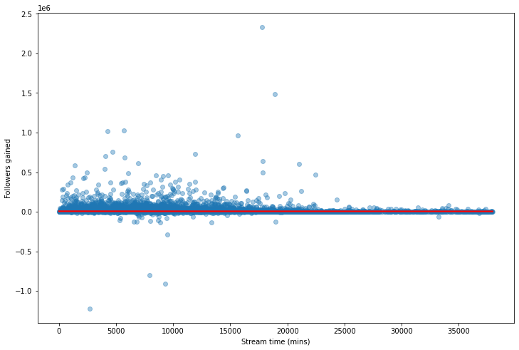

```python
plt.figure(figsize=(12,8))
sns.regplot(x=q5twitch[['Stream time (mins)']], y=q5twitch['Followers gained'], data=q5twitch, scatter_kws={'alpha':0.4},
           line_kws={'color':'r'})
plt.show()
```

The equation of the linear regression line has a negative gradient, so we can expect to gain less subscribers with more stream time. However, the R^2 value of this line is very close to 0, suggesting that a linear regression is not suitable for this graph. This regplot shows a line that is very perfectly horizontal, therefore we conclude that there is no correlation between the stream time and the followers gained.

# Recommendations or Further Works

The dataset for Twitch streamers is not complete and only has the 1st 5100 entries. To get a better understanding for Twitch streamers, a better dataset containing this data must be found.

Besides, the Youtube dataset is not complete, and querying its API returns more recent streams than those from 2015. So, the scraping for older live streams can be broken down into smaller time duration for more results.

It would also be useful to investigate how the like count and duration of live streams for Youtube are related, and more data can be obtained on the proportion of streams of games from specific streamers to investigate the correlation between streams of a certain game and the followers gained on Twitch.

# References

1. https://sullygnome.com/ Twitch data
2. https://trends.google.com/trends/ Trends data
3. https://developers.google.com/youtube/v3/docs/ API for the Youtube data